# Medicare Synthetic Public Use Files

2017-02-17

The following is an exploration of the [Medicare synthetic PUF](https://www.cms.gov/Research-Statistics-Data-and-Systems/Downloadable-Public-Use-Files/SynPUFs/DESample01.html) Sample 1. You can learn more about Medicare data [here](http://www.resdac.org/cms-data).

At this point, I’ll just read the data and select the columns that interest me:

```r
library(tidyverse)
library(readr)

synpuf <-
  feather::read_feather("cache/carclaimsa.feather") %>%
  select(DESYNPUF_ID, ICD9_DGNS_CD_1, ICD9_DGNS_CD_2)

synpuf <-
  bind_rows(synpuf %>% select(ID = DESYNPUF_ID, icd9 = ICD9_DGNS_CD_1),
            synpuf %>% select(ID = DESYNPUF_ID, icd9 = ICD9_DGNS_CD_2))
```

Let’s see what we’ve got:

```r
glimpse(synpuf)
```

```
## Observations: 4,745,914
## Variables: 2
## $ ID   <chr> "00000B48BCF4AD29", "00000B48BCF4AD29", "00000B48BCF4AD29...
## $ icd9 <chr> "7061", "9561", "8241", "V676", "5765", "73320", "24290",...
```

Looking at the codebook for this data, the difference between `ICD9_DGNS_CD_[1:8]` and `LINE_ICD9_DGNS_CD_[1:13]` is that

`ICD9_DGNS_CD_[1:8]` (CLAIM DIAGNOSIS CODE 1 – CLAIM DIAGNOSIS CODE 8) is defined as:

```
The diagnosis code identifying the beneficiary's principal or other diagnosis (including E code). NOTE:
Prior to Version H, the principal diagnosis code was not stored with the 'OTHER' diagnosis codes. During
the Version H conversion the CLM_PRNCPAL_DGNS_CD was added as the first occurrence.
NOTE1: Effective with Version 'J', this field has been expanded from 5 bytes to 7 bytes to accommodate
the future implementation of ICD
–10.
NOTE2: Effective with Version 'J', the diagnosis E codes are stored in a separate trailer
(CLM_DGNS_E_GRP).
Note:
These variables were imputed/suppressed/coarsened as part of disclosure treatment.  Analyses
using these variables should be interpreted with caution.  Analytic inferences to the Medicare population
should not be made when using these variables
```

and the `LINE_ICD9_DGNS_CD_[1:13]` (LINE DIAGNOSIS CODE 1 – LINE DIAGNOSIS CODE 13) is defined as:

```
The code indicating the diagnosis supporting this line item procedure/service on the noninstitutional
claim.
Note: These variables were imputed/suppressed/coarsened as part of disclosure treatment. Analyses
using these variables should be interpreted with caution. Analytic inferences to the Medicare population
should not be made when using these variables.
```

```r
# note that this introduces a blank in place of the character codes. These observations will
# be removed upon coercion to numeric types.

synpuf$icd9 <- gsub(x = synpuf$icd9, pattern = "[A-Z].+", replacement = NA)
```

As an aside, the `str_extract_all` appears to be slower than gsub. If I had to guess, I would say this is an issue with type conversions.

As with any new dataset, I want to see how much missingness we have:

```r
map_dbl(synpuf, ~ length(which(is.na(.))) / length(.)) %>%
  round(digits = 3)
```

```
##    ID  icd9
## 0.000 0.307
```

We're missing a lot of diagnosis codes, but we can still do this analysis. We'll have to keep in mind the possibility of missingness not-at-random when drawing conclusions.

## Dimensionality reduction

The dimensionality reduction afforded by the [Clinical Classification “Software”](https://www.hcup-us.ahrq.gov/toolssoftware/ccs/ccs.jsp) from the Agency for Healthcare Research and Quality project “Healthcare Cost and Utilization Project”. For the purposes of this document, we’ll use the [single-level CCS (note: this link goes to a zip file)](https://www.hcup-us.ahrq.gov/toolssoftware/ccs/Single_Level_CCS_2015.zip).

Here, we’ll read in the CCS tables, keeping only the variabes that interest us, and removing the alphabetical ICD codes just like above:

```r
qcsv <- quietly(read_csv)

#skip the first line because it isn't relevant
ccs_desc <-
  qcsv("ccs/$dxref 2015.csv", skip = 1)$result

names(ccs_desc) <-
  gsub(x = names(ccs_desc), pattern = "\\'|\\-|CATEGORY\\ ", replacement = "")

names(ccs_desc) <-
  gsub(x = names(ccs_desc), pattern = "\\ ", replacement = "_") %>%
  tolower()

names(ccs_desc)
```

```
## [1] "icd9cm_code"              "ccs_category"
## [3] "ccs_description"          "icd9cm_code_description"
## [5] "optional_ccs_category"    "optional_ccs_description"
```

```r
ccs_desc <-
  map_df(ccs_desc, ~ gsub(x = ., pattern = "\\'", replacement = "")) %>%
  select(icd9cm_code, ccs_description) %>%
  mutate(icd9 = gsub(x = icd9cm_code, pattern = "[A-Z].+", replacement = NA)) %>%
  filter(!is.na(icd9)) %>%
  select(-icd9cm_code)

glimpse(ccs_desc)
```

```
## Observations: 12,563
## Variables: 2
## $ ccs_description <chr> "No DX", "Tuberculosis", "Tuberculosis", "Tube...
## $ icd9            <chr> "     ", "01000", "01001", "01002", "01003", "...
```

ICD9 codes can be 3, 4, or 5 digits. The 3- and 4- digit CCS ICD9 codes all start with 0 and 00, respectively, whereas the the synthetic PUF ICD9 codes do not. We’ll have to fix that:

```r
ccs_desc$icd9 <-
  gsub(x = ccs_desc$icd9, pattern = "^0+", replacement = "")

glimpse(ccs_desc)
```

```
## Observations: 12,563
## Variables: 2
## $ ccs_description <chr> "No DX", "Tuberculosis", "Tuberculosis", "Tube...
## $ icd9            <chr> "     ", "1000", "1001", "1002", "1003", "1004...
```

And here, we’ll join the two dataframes

```r
synpuf_ccs <-
  inner_join(synpuf, ccs_desc) %>%
  select(-icd9)
glimpse(synpuf_ccs)
```

```
## Observations: 1,644,636
## Variables: 2
## $ ID              <chr> "00000B48BCF4AD29", "00000B48BCF4AD29", "00000...
## $ ccs_description <chr> "Oth infectns", "Ot bone dx", "Thyroid dsor", ...
```

Cool! We’ve got a list of patient-diagnoses.

Next, we’ll reshape the data:

```r
synpuf_ccs <-
  synpuf_ccs %>% filter(!is.na(ID) & !is.na(ccs_description))

synccs_wide <-
  data.table::dcast(synpuf_ccs, formula = ID ~ ccs_description,
                    fun.aggregate = function(x) ifelse(sum(!is.na(x)) > 0, TRUE, FALSE))
```

And we’ll clean up the casted data a little:

```r
synccs_wide$`No DX` <- NULL
synccs_wide$Unclassified <- NULL

names(synccs_wide) <-
  gsub(x = tolower(names(synccs_wide)), pattern = "\\s|\\-|\\/|\\;", replacement = "_")

synccs_wide$id <- NULL
```

So here’s what we’ve got:

```r
glimpse(synccs_wide[,1:10])
```

```
## Observations: 47,659
## Variables: 10
## $ 2ndary_malig              <lgl> FALSE, FALSE, FALSE, FALSE, FALSE, F...
## $ abdom_hernia              <lgl> FALSE, FALSE, FALSE, FALSE, FALSE, F...
## $ abdomnl_pain              <lgl> TRUE, TRUE, FALSE, FALSE, FALSE, TRU...
## $ acq_foot_def              <lgl> FALSE, TRUE, FALSE, FALSE, FALSE, FA...
## $ acute_cvd                 <lgl> TRUE, TRUE, FALSE, FALSE, FALSE, TRU...
## $ acute_mi                  <lgl> TRUE, TRUE, FALSE, FALSE, FALSE, FAL...
## $ adjustment_disorders      <lgl> FALSE, FALSE, FALSE, FALSE, FALSE, F...
## $ adlt_resp_fl              <lgl> FALSE, FALSE, FALSE, FALSE, FALSE, F...
## $ alcohol_related_disorders <lgl> FALSE, FALSE, FALSE, FALSE, TRUE, FA...
## $ allergy                   <lgl> FALSE, FALSE, FALSE, FALSE, FALSE, F...
```

Also, solely in reshaping the data, we have lost some information. Our aggregation function reports only the presence of a diagnosis code, rather than the number of times that the patient was listed with that code.

## Figuring out associations

One popular R package, `arules` calls a C implementation of an algorithm (apriori, by C. Borgelt) that we can use to produce our network edge list. Moreover, we can calculate relevant metrics such as odds ratios and chi-square tests of difference if we are interested in presenting this data to the traditional physician/clinical crowd. In fact, now that I think about it, it might be worth implementing a Bonferroni correction or Tukey’s Honest Significant Difference to help people make sense of the mass of results.

Here, we’ll use the `arules` package to produce our adjacency matrix and calculate some useful values. Note that `arules` considers each patient (row) a transaction and each diagnosis (column) an item.

```r
#rm(list = ls()[-grep("synccs_wide", ls())])

library(arules)

sync_tx <- as(synccs_wide, "transactions")

rule_params <- list(supp = 0.05, conf = 0.5,
                    maxlen = 2, target = "rules")

sync_rules <-
  apriori(sync_tx, parameter = rule_params)
```

```
## Apriori
##
## Parameter specification:
##  confidence minval smax arem  aval originalSupport maxtime support minlen
##         0.5    0.1    1 none FALSE            TRUE       5    0.05      1
##  maxlen target   ext
##       2  rules FALSE
##
## Algorithmic control:
##  filter tree heap memopt load sort verbose
##     0.1 TRUE TRUE  FALSE TRUE    2    TRUE
##
## Absolute minimum support count: 2382
##
## set item appearances ...[0 item(s)] done [0.00s].
## set transactions ...[206 item(s), 47659 transaction(s)] done [0.04s].
## sorting and recoding items ... [100 item(s)] done [0.02s].
## creating transaction tree ... done [0.02s].
## checking subsets of size 1 2 done [0.01s].
## writing ... [1178 rule(s)] done [0.00s].
## creating S4 object  ... done [0.01s].
```

```r
qinspect <- quietly(arules::inspect)

df_rules <- data.frame(qinspect(sync_rules)$result)

df_rules <- df_rules %>% select(-2)

head(df_rules[200:205,])
```

```
## data frame with 0 columns and 6 rows
```

Again, to make things easier, we’re limiting ourselves to only diagnosis-diagnosis associations. It is possible to consider any number of items in each set, but I have yet to experiment with visualizing hyperedges.

Before making a networks-type visualization, let’s see what kind of results we’ve got. I’ll plot odds ratio against support, representing (the odds of the left hand side divided by the odds of the right hand side) plotted against (the proportion of transactions with the left hand side item)

[figure not shown]

Odds Ratios and Chi-Square Statistics

```r
library(viridis)

# df_rules <-
#   df_rules %>%
#   mutate(OR = interestMeasure(sync_rules, measure = "oddsRatio", transactions = sync_tx),
#          chi_square =  interestMeasure(sync_rules, measure = "chiSquared", transactions = sync_tx))
df_rules$chi_square <- interestMeasure(sync_rules, measure = "chiSquared", transactions = sync_tx)
df_rules$OR <- interestMeasure(sync_rules, measure = "oddsRatio", transactions = sync_tx)

#test <- interestMeasure(sync_rules, measure = c("oddsRatio", "chiSquared"), transactions = sync_tx)

ggplot(df_rules, aes(support, OR, color = chi_square)) +
  geom_point(alpha = I(1/2)) +
  labs(x = "Proportion of transactions with left hand side diagnosis",
       y = "Odds ratio", title = "Odds ratios for all associations") +
  scale_color_viridis()
```

## Network Visualization

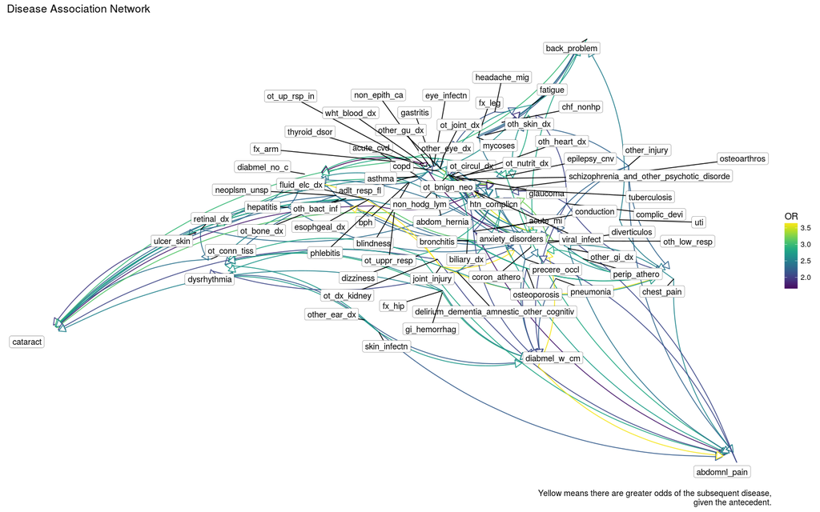

Network Visualization

```r
library(network)
library(ggnetwork)

df_rules_sample <- df_rules %>% sample_n(150) %>% filter(OR < 3.8)

make_quantile <-
  ecdf(df_rules$chi_square)

sync_net <-
  network(x = select(df_rules_sample, lhs, rhs),
          vertex.attr = list(df_rules_sample$support,
                             df_rules_sample$OR,
                             make_quantile(df_rules_sample$chi_square)),
          vertex.attrnames = c("Support", "OR", "XSquare"),
          directed = TRUE)

set.seed(123123)

#Trying out different layouts for size
#sync_gg <- ggnetwork(sync_net, layout = "target")
#sync_gg <- ggnetwork(sync_net, layout = "adj")
sync_gg <- ggnetwork(sync_net, layout = "geodist")
#sync_gg <- ggnetwork(sync_net, layout = "hall")
#sync_gg <- ggnetwork(sync_net, layout = "seham")
#sync_gg <- ggnetwork(sync_net, layout = "springrepulse")

ggplot(sync_gg, aes(x = x, y = y, xend = xend, yend = yend)) +
 # geom_segment(aes(color = XSquare)) +
  geom_edges(aes(color = OR), arrow = arrow(length = unit(10, "pt"), type = "closed"), curvature = 0.2) +
  geom_nodelabel_repel(aes(label = gsub("(\\{|\\})", "",
                             as.character(sync_gg$vertex.names))), label.size = 0.1) +
  theme(legend.position = "none") + theme_blank() +
  labs(x = "", y = "", title = "Disease Association Network",
       caption = "Yellow means there are greater odds of the subsequent disease,\n given the antecedent.") +
  scale_color_viridis()
```

So, those were some cool visualizations.

## Naive Bayes

Knowing that one focus of your program is predictive modeling, here’s a naive bayes model predicting tuberculosis:

```r
library(e1071)

tuberculosis_model <-
  naiveBayes(tuberculosis ~ ., data = synccs_wide)

head(tuberculosis_model)[[2]][205]
```

```
## $wht_blood_dx
##        wht_blood_dx
## Y            FALSE       TRUE
##   FALSE 0.95555556 0.04444444
##   TRUE  0.87397468 0.12602532
```

As an example, it looks like about 12.6% of people with tuberculosis also had a white blood cell diagnosis. In contrast, people without tuberculosis had white blood cell diagnoses at a rate of 4.4%. We can look through all of the diseases for interesting ones, too, if we are looking for explanatory information. Of course, we can use the conditional probabilities to make predictions regarding tuberculosis status, as well.

Future directions: While the naive bayes is cool, one of my upcoming goals is to design a bayesian network based on domain knowledge (physiology) and learn it from diagnosis data.